```python
%pylab inline
import pandas as pd
```

```
WARNING: pylab import has clobbered these variables: ['f', 'cov']
`%matplotlib` prevents importing * from pylab and numpy
```

# Class Project

The project is due in the last week of the class, to be done by groups of four students.

Every team must:

- make a 15 min presentation, plus 5 min for Q/A
- submit the source code used for the presentation, including .ipynb and .py

The project will be graded on:

- technical merits, including correctness, completeness and creativity
- presentation skills, clarity, persuasiveness and salesmanship

## Background

You are advising a client, Ms. Rich, who owns a successful business. Ms. Rich is planning to retire in three years, she is extremely confident that she can find a suitable buyer for her business soon (definately within 3 years). Ms. Rich is interested in protecting her net worth, which is largely locked in her company, against any adverse business environment in the next 3 years. The earnings of Ms. Rich's company is mostly tied to the its three big customers, JNJ, PG and MMM. Ms. Rich believes that a equally weighted portfolio in JNJ, PG and MMM is the key risk factor of her company, if the value of that portfolio loses 50% of its current value, then Ms. Rich's company will suffer major financial loss due to lack of orders from its largest customers. Ms. Rich wants protection against such severe risk for the next 3 years.

Ms. Rich has been talking with her financial advisors at Giltman Shakes & Co., and they offered her a knock-in barrier put option, with monthly observation dates. The terms of the barrier option are:

- Inception and exipry date: the option starts on the 1st day of the month, expires on a month end 3Y after its inception.
- Reference basket: consists of three stocks of [JNJ, PG, MMM] with equal dollar weights at the trade inception
- Observation dates: every month end before the option expiration, including the final maturity date (which is on a month end).
- Trigger event: the basket value is below 50% of its starting value on any of the observation dates. It does not trigger if the basket value dips below 50% betweewn the observation dates, but comes back above the 50% barrier on the next observation date.
- Payoff: if triggered, Giltman Shakes will pay $ \left(\$10,000,000.00 \times \frac{s(0) - s(3Y)}{s(0)}\right)^+$ at option maturity (i.e., t = 3Y), where $s(t)$ is the value of the basket at time $t$. Essentially, when the barrier is breached, the instrument turns into an European put with \$10MM notional amount.
- The option expires worthless at t=3Y if the barrier is not breached on any of the observation dates.
- Ms. Rich cannot manage collateral as her company is not a financial institution, therefore neither party posts or receives any collateral during the life time of the trade.

Ms. Rich likes the proposed trade, and she wants your expert opinions. She does have some concerns: Even though Giltman Shakes is a reputable firm, it had gone to the brink of bankrupcy during the financial crisis. Ms. Rich is rightfully worried about Giltman Shakes' ability to pay. In case if Giltman Shakes is in default and the reference basket breaches the 50% barrier, Ms. Rich is expected to receive only 40% of the promised payoff through the bankrupcy litigations. Ms. Rich has raised this concern to Giltman Shakes, the traders in Giltman Shakes offered her a 2% discount from the option's fair value, which is the valuation without taking into account any counterparty default risk. Giltman Shakes' trader claims it is a generous offer because the firm currently has a single A credit rating, and the historical default probability of single A firms over 3Y is only 0.5%, and the expected recovery of Giltman Shacks is 40%.

## Market condition

We observe the following market condtions:

- risk free interest rate is a flat curve of $r = 0.02$
- the stock of Giltman Shakes follows very closely to the stock of GS, thus you can use GS stock as a proxy for Giltman Shakes stock
- expected recovery for Giltman Shake's senior unsecured debt is 40%, counterparty obligation is a form of secure unsecured debt.
- CDS quotes on Giltman Shake's senior unsecured debt are:

```python
import inst
import fmt

r = 0.02
def flatCurve(rate) :
    return lambda t : np.exp(-rate*t)

disc = flatCurve(r)

terms = np.array([.25, .5, 1., 2, 3, 4, 5, 6, 7, 8, 10])
qs = np.array([85, 95, 110, 130, 140, 147, 155, 160, 165, 168, 170])
recovery = 0.4

cps = np.ones(len(terms))*100
insts = [inst.CDS(m, c*1e-4, recovery) for m, c in zip(terms, cps)]

#compute the upfront PV of the benchmark instruments
ufr = np.array([i.pv01(disc, flatCurve(f*1e-4))*(c-f)*1e-4 for i, f, c in zip(insts, qs, cps)])

mat_tag = 'Maturity (Y)'

cds_data = pd.DataFrame({mat_tag:terms, 'Coupon(bps)':cps, 'Quoted Spread(bps)':qs, 'PV (% Points)': ufr*100.}).set_index(mat_tag)
fmt.displayDF(cds_data.T, "4g")
```

| Maturity (Y) | 0.25 | 0.5 | 1.0 | 2.0 | 3.0 | 4.0 | 5.0 | 6.0 | 7.0 | 8.0 | 10.0 |
| --- | --- | --- | --- | --- | --- | --- | --- | --- | --- | --- | --- |
| Coupon(bps) | 100 | 100 | 100 | 100 | 100 | 100 | 100 | 100 | 100 | 100 | 100 |
| PV (% Points) | 0.03723 | 0.02473 | -0.09808 | -0.5782 | -1.136 | -1.748 | -2.509 | -3.223 | -3.997 | -4.691 | -5.824 |
| Quoted Spread(bps) | 85 | 95 | 110 | 130 | 140 | 147 | 155 | 160 | 165 | 168 | 170 |

## Modeling tasks

There are several required modeling steps in this projects:

1. Build a CDS curve for Giltman Shakes, and compute its market implied default probability term structure.
2. Price the fair value (without the counterparty risks) of the barrier option using Monte Carlo simulation. Please feel free to make your own assumptions, or use available historical data to estimate necessary parameters.
3. Apply one variance reduction technique, you get more credits for more savings in computational time. There can be more than one good choices, use your creativity.
4. Compute the value of the barrier option with the default risk of Giltman Shakes, and advise Ms. Rich whether she should take the 2% discount offer.

The following are optional steps that will earn you extra credit:

1. Propose any alternative structures that might serve Ms. Rich's needs better, you may win over her business from the Giltman Shakes,
2. Risk and hedging, if you were the dealer from Giltman Shakes who takes the opposite side of the trade, what are the main risk factors and how would you hedge this barrier option.

Hints:

- If you are considering control variate, PDE could be a useful way to value your control variate.
- For step 4, you'd need to simulate Giltman Shake's default time, the simplest way is to consider Giltman Shakes has defaulted if its stock price goes below a threshold, which can be calibrated to the default probability. In reality, after a company defaults, its stock price goes to 0 permanently. For this project, you can assume that company could come back to life from bankruptcy, and its stock continues to follow GBM even in default. This assumption simplifies the calibration of the default threshold and the simulation of default events, you only need to check if the Giltman Shakes' stock is below the calibrated threshold at the final maturity of the barrier option, you do not need to track if Giltman Shakes has defaulted prior to the maturity date. This assumption is clearly wrong, but it does not affect the main point we are trying to capture here.
- We have CDS implied and rating based default probabilities for Giltman Shakes, it is important to think about and explain which default probability you should use in oder to price the option and why.

## Presentation

Once you have done your research, you need to present your findings to Ms. Rich. Ms. Rich is a highly intelligent person, but she is unfamilar with financial models. Therefore, you have to present your findings in a way that she can understand, and advise her on the fair value of the option and whether she should take Giltman Shakes' offer of 2% discount. You should include the technical details in the appendix slides, and walk them through them after the main presentation to Ms. Rich.

In your presentation, please show the following results:

In the main presentation to Ms. Rich (suggest 10min):

1. your pricing assumptions, data used etc (like historical covariance, market data etc).
2. explain the choice of your default probability used for pricing and why
3. explain how you did the pricing in layman's term that Ms. Rich can understand, you need to explain what drift you used to simulate stock prices and why.
4. the CDS implied default probability term structure of Giltman Saches
5. the fair value of the option, and the value with the counterparty default
6. is defprob*(1-recovery) a fair discount for Giltman Shakes default probability? explain why
7. propose any alternative struture that may meet Ms. Rich's needs better

In the technical appendix (suggest 5 min):

1. the input covariance matrix, and the covariance matrix estimated from your simulated paths
2. show the simulated default probability of Giltman Saches, and compare that to the target level
3. what is your variance reduction technique when pricing the fair value, how much computational time it saved?
4. any risk and hedging consideration
5. contribution percentage of each team members (if you can all agree), you earn 40% extra credits for the team by doing this.

# Technical Solution

1: the CDS implied default probability of Giltman Shakes:

```python
benchmarks = dict(zip(insts, ufr))
xs = np.arange(.01, 10, .01)
lbd = 5

cdspv = inst.cdspv(disc, inst.zero2disc)
tsit0, e0 = inst.iterboot(benchmarks, cdspv, lbd=lbd, x0=0, its=1)
```

```python
dp = 1. - np.exp(-tsit0(terms))

df = pd.DataFrame({mat_tag:terms, 'G/S default prob': dp}).set_index(mat_tag)
fmt.displayDF(df.T, "4g")
```

| Maturity (Y) | 0.25 | 0.5 | 1.0 | 2.0 | 3.0 | 4.0 | 5.0 | 6.0 | 7.0 | 8.0 | 10.0 |
| --- | --- | --- | --- | --- | --- | --- | --- | --- | --- | --- | --- |
| G/S default prob | 0.00352 | 0.007853 | 0.01811 | 0.04239 | 0.06781 | 0.09395 | 0.1226 | 0.1502 | 0.1787 | 0.2055 | 0.2537 |

```python
import scipy
import mkt

ns = ['JNJ', 'PG', 'MMM', 'GS']
stock_prices = mkt.download_hist_stock(ns).sort()

logret_daily = np.log(stock_prices).diff()[1:]
cov = logret_daily.cov()*250

n, tm, thr = 10e6, 3, .5

nf = len(ns)
```

```python
import proc

def barrier_payoff(obs, thr, defaulted) :
    breached = np.any(np.less(obs, thr))
    v = 0
    if breached : #breached barrier
        v = disc[-1]*np.maximum(1. - obs[-1], 0.)
        if (defaulted) :
            v *= recovery

    return v

obs_freq = 12
samples_per_period = 10
dt = 1./(obs_freq*samples_per_period)
obs_idx = np.arange(samples_per_period, tm*obs_freq*samples_per_period+1, samples_per_period) - 1

npath = 5000
ts = np.arange(dt, tm+1e-10, dt)
disc = np.exp(-r*ts)

mgbm = proc.MF_GBM(np.ones(nf)*r, cov)

x0 = np.ones(nf)
defprob = 1. - np.exp(-tsit0(ts))

es = np.random.normal(size=[npath, len(ts), nf])
paths = mgbm.draw(es, x0, dt)

gs = paths[:, :, -1]
def_thr = np.array([np.percentile(s, 100.*d) for s, d in zip(gs.T, defprob)])
sim_dp = np.array([1.*np.sum(np.less(s, d)) for s, d in zip(gs.T, def_thr)])/npath
```

```python
arith_avg = lambda x : np.mean(x[obs_idx, :-1], 1)
geom_avg = lambda x : np.exp(np.mean(np.log(x[obs_idx, :-1]), 1))

bv = []
rv = []
cv = []
covs = []

for xs in paths :
    gs_defaulted = xs[-1, -1] < def_thr[-1]
    bv.append(barrier_payoff(arith_avg(xs), thr, False))
    rv.append(barrier_payoff(arith_avg(xs), thr, gs_defaulted))
    cv.append(barrier_payoff(geom_avg(xs), thr, False))

    covs.append(np.cov(np.diff(np.log(xs.T)))/dt)

bv = np.array(bv)
rv = np.array(rv)
cv = np.array(cv)
```

2: the historical and simulated covariance matrix

```python
c = np.corrcoef(bv, cv)[0, 1]
print "correlation %.2f, max variance reduction using control variate is %.2f" % (c, 1./(1-c*c))
scov = pd.DataFrame(np.mean(covs, 0), index=ns, columns=ns)
fmt.displayDFs(cov, scov, headers=["Input Covariance", "Simulated Covariance"])
```

```
correlation 0.94, max variance reduction using control variate is 8.67
```

Input Covariance

Simulated Covariance

|  | JNJ | PG | MMM | GS |
| --- | --- | --- | --- | --- |
| JNJ | 0.04057 | 0.0192 | 0.02032 | 0.02265 |
| PG | 0.0192 | 0.05255 | 0.02178 | 0.0209 |
| MMM | 0.02032 | 0.02178 | 0.05747 | 0.04175 |
| GS | 0.02265 | 0.0209 | 0.04175 | 0.1581 |

[output not shown]

3: simulated and CDS implied default probability

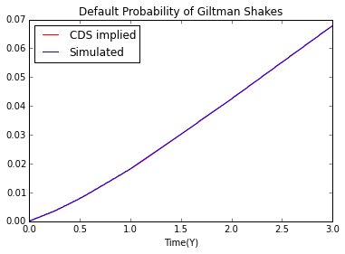

```python
plot(ts, defprob, 'r')
plot(ts, sim_dp, 'b')
xlabel('Time(Y)')
legend(['CDS implied', 'Simulated'], loc='best')
title('Default Probability of Giltman Shakes');
```

4: fair value and the valuation with the adjustment of Giltman Shake's default.

```python
fair_v = np.mean(bv)*n
real_v = np.mean(rv)*n

print "the fair value of this option is %.2f, mc error is %.2f" % (fair_v, np.std(bv)/np.sqrt(npath)*n)
print "the real value of this option is %.2f, mc error is %.2f" % (real_v, np.std(rv)/np.sqrt(npath)*n)
```

```
the fair value of this option is 167480.75, mc error is 12652.30
the real value of this option is 137205.81, mc error is 10919.03
```

5: the valuation adjustment for Giltman Shake's own default is. It is a lot higher than the default probability implied adjustment of 0.07*.6 = 4.2%, because of the wrong way risk, i.e., Giltman Shakes is more likely to be in default when the basket lose half of its value, due to the positive correlation effects.

```python
print "CVA adjustment is %.2f %%" % ((fair_v - real_v)/fair_v*100.)
```

```
CVA adjustment is 18.08 %
```